# GEOG 101

## Ch 1: Introduction to Human Geography

- Pages: 2-33
- The Arab Spring was the result of many global events that led to higher bread prices
- **Places**: specific geographic settings with distinctive physical, social and cultural attributes
  - Physical setting for human activity
  - Dynamic
  - Shapes human values, attitudes, behaviours
  - Influences well-being, opportunities and future lives
  - Meaning is subjective
- **Regions**: territories that encompass many *places* that share attributes
- Geography helps us understand the world
- **Human Geography**: study of spatial organization of human activity and people’s relationships with their environment

### Places

- Dynamic - changes properties and boundaries due to environment and human factors
- Influences people’s physical well-being, opportunities, lifestyle choices
- Places hold meaning for different people
- **Identity**: the sense that you make of yourself through your subjective feelings based on your everyday experiences and social relations
- Significant events occur in places
- Social interaction occurs in places
  - Structures daily routines
  - Provides opportunities and constraints
  - Context for common-sense and experience
  - Setting for socialization
  - Arena for contesting social norms

### Human Geography

- **Physical Geography**: Earth’s natural processes and outcomes
  - e.g Climate, weather, land forms, soils, surface water, plants and animals
- **Regional Geography**: How environmental and human factors produce territories with distinctive landscapes and cultural attributes
  - Combination of Physical and Human geography
  - e.g Resources and hazards, environmental impacts
- **Human Geography**: study of spatial organization of human activity and people’s relationships with their environment
  - e.g Cultural, religious, political systems
  - e.g Recreation, tourism, transportation, human settlements, economic systems, population
- Tools
  - Observation
    - Fieldwork
    - Lab experiments
    - Remote sensing (Using aerial photography / satellite imagery to collect information)
  - Visualization and Representation
  - Analysis

#### Maps

- Representations of the world
- Reveals ‘invisible’ patterns and features
- What they contain and omit reveal experiences, priorities, interpretations and intentions of their authors
- Types
  - Topographic: Form of earth’s surface
    - Contour lines connect equal elevation
  - **Thematic**: Shows the distribution, flow or connection of characteristic
    - **Isoline** maps have lines connecting equal data value
      - e.g precipitation
    - Proportional symbols use density to represent frequency
  - **Dot**: Single dot/symbol for number of occurrences
    - Shows dispersion or clustering of a distribution
  - **Choropleth**: Shows quantity or type of phenomena by area
    - e.g Shaded heat maps
- Map scale: ratio between linear distance on a map and linear distance on Earth’s surface
  - Corresponding lengths or Representative fraction (ratio)
- Map projections: systematic rendering of earth on a flat surface
  - Equidistant: distance is accurate in one direction
    - e.g Polyconic
  - Conformal: renders compass directions accurately
    - e.g Mercator
  - Azimuthal: compass directions are correct only from one point
    - e.g Azimuthal equidistant
  - Equivalent / Equal-area: Areas are portrayed in true proportions
    - e.g Mollweide
  - Robinson projection: looks nice
    - e.g National Geographic
  - Cartogram: space is transformed based on some stat
    - e.g Relative country size based on proportion of people living on <$10 a day

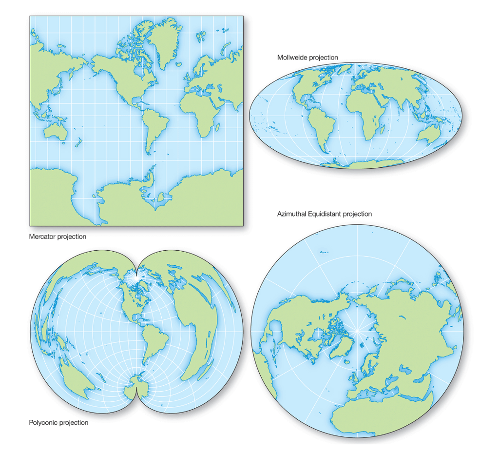

#### Geographic Information Systems (GIS)

- Organized set of computer hardware, software and spatially coded data to capture, store, update, manipulate, and display geographic references
- Data must have longitude, latitude, elevation
- Allows merging of data from different sources and topics
- Benefits
  - Easy customization and updating
  - Precision and accessibility
  - Anyone can contribute
  - Initial high cost, then low cost to maintain
  - Incorporates complexity
  - Multi-scalar (can be of different scales)
  - Data linked to location

### Spatial Analysis

- Study of geography as their arrangement on a map
- Movement and interconnections between places
- e.g Travel times between places

#### Location

- Can be
  - Nominal: names
  - Absolute: precise coordinates
    - **Latitude** = how north / south
    - **Longitude** = how east / west
  - **Relative**: position relative to other features
    - in terms of site or situation
      - Site: physical attributes of location (terrain, soil, etc)
      - Situation: location relative to other places / activities
  - Cognitive (**mental map**): psychological representations of locations
    - Reveals knowledge, priorities, psychology, lack of awareness, incorrect knowledge
    - Used to identity service gaps, awareness gaps, invisible (e.g gang) features, differences between people, personal attributes

#### Distance

- Absolute: in km
- Relative: in terms of time, effort, or cost
- Cognitive: perceived distance
- **Friction of distance**: Distance exerts a ‘force’
  - deterrent / inhibiting effect of distance on human activity
- **Distance-decay function**: Near things are more related than distant things
  - rate where an activity decreases with distance
  - e.g Don’t commute to Waterloo for a job
- **Frictionless zone**: distance where you’re so close it doesn’t matter
- **Nearness principle**
  1. Max overall utility of places at min effort
  2. Max connections between places at min cost
  3. Locate related activities close together

#### Space

- Absolute
- Topological: connections between points in space
  - Measured by nature and degree of connectivity
- Relative:
  - Socioeconomic: measures of cost, profit, productivity
  - Cognitive: People’s values, feelings, beliefs, perceptions
- Activities produce space (e.g setting up a town center)

#### Accessibility

- Opportunity for contact/interaction from a location relative to other locations
- *Connectivity*: channels of communication and transportation

#### Spatial Interaction

- Influences use of space:
  - Awareness, cultural tendencies, money, transportation modes, distance
- Movement and flows involving human activity
- Principles
  - **Complementarity**
    1. Supply in one place and demand in another
    2. International division of labour
    3. Specialization + economies of scale
  - **Transferability**
    - Acceptable cost and timing
    - Cost of moving an item vs ability of item to bear costs
    - Improved by *infrastructure* and *time-space convergence*
  - **Intervening opportunities**
    - Alternative origins or destinations
    - e.g closer destinations
- Spatial diffusion
  - How things (e.g innovation, disease, politics, music) spread through space and time
  - **Expansion**: spread due to proximity
  - **Hierarchical**: spread that skips in-between places
  - **Relocation**: spread due to people movement
    - e.g Emigrating to another country

### Regional Analysis

- Similarities and differences among and between places
- e.g Entertainment District in GTA
- Problem: no clear borders
- Solution: use attributes
  - Physical attributes: terrain, climate, resources, soils, vegetation
  - Cultural attributes: practices, architecture, businesses, religious structures, human landscape modifications

#### Regionalization

- Classifying *areal units* (individual places)
- Look at regions with coherent structure, economics, politics, social organization
- *Core-Domain-Sphere* model:
  - **Core**: All attributes present
    - Distinctive attribute very clear
  - **Domain**: Most attributes present
    - Dominant, but not exclusive
  - **Sphere**: Some attributes present
    - Present, but not dominant

#### Landscape

- Complex repository of society
- **Ordinary** (vernacular) landscape: everyday landscapes created from life
  - Influences perceptions, values, behaviours
  - Dynamic (changes over time)
  - e.g Highway traffic
- **Symbolic** landscape: particular values / aspirations leaders want to impart on the public
  - Represents values and aspirations
  - National identity
  - Protected ‘as is’
  - e.g Great Wall

#### Sense of Place

- People’s feelings towards a place due to lived experiences and memories
- e.g Culture, ‘way of life’, sports teams, cuisine, landscape, regional identity
- Insiders
  - Shared dress code, speech patterns
  - ‘Third places’
- Outsiders
  - Local landmarks, ways of life that are familiar

## Ch 3: Population Geography

- Pages: 72-109
- Population counts are political
  - Determines number of representatives in government
  - Determines amount of tax revenue the region receives
  - e.g Iraq does not want to conduct a census because it will determine who controls the oil fields
- **Demographics**: characteristics of a *human population* including gender, race, age, income, disabilities, education, migration patterns

### Demographic Tools

- **Demography**: Study of characteristics of human populations
- Try to study distribution of people
- **Census**: Count of people in a country / region / city
  - Lots of data
  - Only a snapshot
- **Intercensal Estimates**
- **Vital records**: reports of birth, death, marriage, divorce, disease
  - Limited individuals
  - Tracks changes over time
- Combining census and vital record gives more information, but has privacy implications
- Limitations:
  - Expensive
  - Not comprehensive (underrepresents non-mainstream households)
- India held a biometric census that was cheap and thorough

#### Population Distribution and Structure

##### Population Distribution

- Population is shaped by
  - accessibility, topography, soil fertility, climate, water, natural resources
  - a country’s politics and economics
  - religious reasons
- Distribution:
  - Asia is most populated
  - Most people are near oceans or rivers
  - 90% people are north of equator
  - Mostly in temperate places (no arctic or mountaintops)

##### Population density and composition

- **Crude Density**: number of people / total land area
- **Nutritional Density**: total population / cultivated land
- **Health care density**: total population / number of physicians
- Composition information
  - Proportion of older people helps us allocate health care
  - Proportion of child-bearing aged females helps predict population growth
    - Also education of females

##### Age-Sex pyramids

> GOOD EXAM QUESTION
- Predicts future population size
- e.g Can reveal effects of WWI, WWII on Germany’s population
- Rapid growth pyramid (Peripheral Country):
  - Wider base than middle
  - Need resources to care for children
  - Need to create more jobs when children grow up
- Slow/No growth pyramid (Core country):
  - More middle cohort than youth
  - Below replacement level
  - Population evenly distributed among cohorts
- *Dependency Ratio*: economic impact of young and old on working members of population
- Cohorts:
  - Youth: <15 years
  - Middle: age 15 - 64
  - Old: >65 years
- Baby Boom
  - Occurred after WWII
  - Caused by positive outlook of life
  - Ended by contraceptives and women entering workforce
  - Currently more older people than children

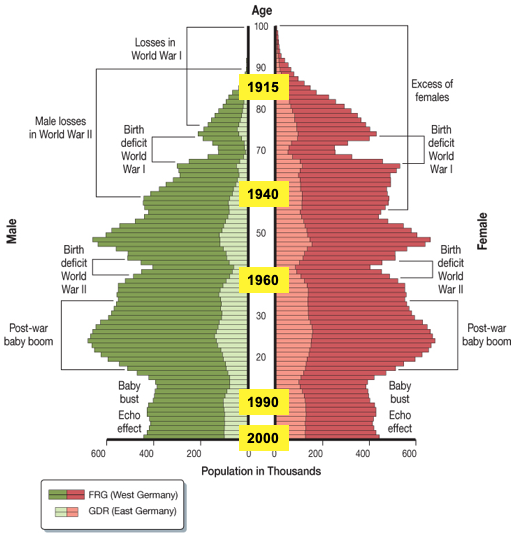

### Population Dynamics and Processes

- Population Growth = Births - Deaths + (Immigration - Emigration)
- **Rate of Natural Increase (RNI)** = CBR - CDR (doesn’t include immigration)
  - High RNI indicates less developed country

#### Birth Rates

- **Crude birth rate**: live births in a year / every thousand people
  - Rich countries have lower CBR
  - High CBR means
    - Young population
    - Low education levels
    - Underemployment (esp women)
    - Low availability of birth control
    - Less developed country
- **Total fertility rate**: average number of children a woman will have during her childbearing years (15-49)
  - High TFR implies less developed country

#### Death Rates

- **Crude death rate**: deaths in a year / 1000 People
  - High CDR means
    - Poor healthcare
    - Lack on government investment in health
    - Poor parents
    - Less developed country or aging population
- Men and elderly have higher death rates
- Poorer groups have higher death rates
- Variations
  - **Infant mortality rate**: infants deaths < 1 year / 1000 live births
  - **Life expectancy**: average number of years an infant is expected to live
    - Differs by sex and race
- Epidemics affect life expectancy
  - HIV/AIDS
    - USA: more drug users and homosexual males
    - Canada: more aboriginals and inmates
    - Africa: more hetero-sexual non-drug users

#### Demographic Transition Theory

> GOOD EXAM QUESTION
- Theory that as a country modernizes, fertility and mortality rates will drop, but at different times
  - Occurs with higher economic production and standards of living
  - First death rate falls, then birth rate falls
    - Rapid population increase during this time
  - Based on industrialized countries. May not be generalizable to peripheral countries
- Phases
  1. Pre-industrial: High birth and death rate, low population
  2. Transitional: Dropping death rate, growing population
  3. Transitional: Low death rate, dropping birth rate, growing population
  4. Industrial: Low birth and death rate, high population
  5. (Post-Industrial): Slightly-increasing death rate, dropping population

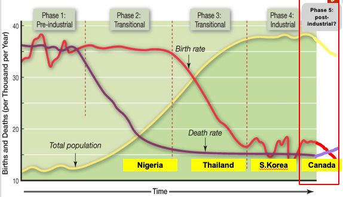

### Population Movement and Migration

- Migration changes population

#### Mobility and Migration

- **Mobility**: ability to move from a place to another
  - *cyclical* or *permanent*
  - short or long distance
- **Migration**: long-distance, long-term move to a new location
  - change of residence
- Migration is tracked
  - Leaving skilled workers in Cuba
  - Influx of cheap migrants in US
  - ‘Brain drain’
- **Gross Migration**: Total number of migrants moving in or out
- **Net Migration**: gain or loss in population due to migration
- Controls for migration
  - Distance and distance decay
  - Intervening opportunities
  - **Push factors** cause people to move away
    - Environmental factors:
      - land degradation
      - natural hazards
      - sea levels
      - pollution
      - *climate change*
    - Diseases
  - **Pull factors** attracts people to a place
- Degree of choice
  - *Voluntary*
    - Economic migrants (work)
    - Accompany family members
    - Education
    - Land
  - *Reluctant*
    - Conflict
    - ethnic cleansing
    - internal relocation
    - environmental refugees
  - *Forced / Involuntary*
    - War
    - slavery
    - forcible repatriation
    - natural disasters
    - Natural disaster displacement is short-term vs conflict displacement
- Consequences of migration
  - Demographic: changes size, age, ethnicity of population
  - Economic: positive or negative
  - Social: cultural assimilation or conflict

#### International Voluntary Migration

- Canada receives a lot of voluntary immigrants
  - Initial settlers from Asia
  - French and British
  - Asian immigrants
- **Transnational migrants**: migrants with homes in multiple countries
  - e.g HK people that bought Vancouver housing
- Temporary labour migration: when workers go abroad and send money back
  - Reduces unemployment back home
  - Money from workers sending remittances back

#### International Forced Migration

- Refugees and Internally Displaced Persons (IDPs)
  - Only 1/3 of people leaving cross a border
- Reasons
  - War
    - e.g War on Terror in Iraq
    - e.g Arab-Israeli War
  - Famine
  - Government coercion or oppression
  - Slavery from Africa
  - Modern slavery
    - Undocumented workers cannot go to authorities
  - Natural disasters
  - Eco-migration
    - Due to degradation of land and natural resources
    - e.g Flat islands (Maldives, Seychelles)

#### Internal Voluntary Migration

- People move due to economic opportunities in provinces
- Population changes - migrants are usually young and educated
- China: Large migration of rural to urban
  - Government wants to increase industrial productivity

#### Internal Forced Migration

- Political decisions
- IDPs: Internally-displaced people. Growing in number
- China: cultural revolution ‘Down to the Countryside Movement’
- USA: Aboriginals were forced to leave their homelands
- Canada: Relocated Inuit people to High Arctic

### Population Debates and Policies

- How many people can Earth sustain?

#### Population, Resources, and the Environment

- Malthus: Population growth will exceed available resources
- Need to prevent population from outgrowing available jobs and resources

#### Population Policies

- Official government strategy to change the size, composition or distribution of a population
- Urbanization naturally decreases fertility rate
- Other population control
  - Offer contraceptives
  - Family planing
  - Incentives to have less children
  - Educate women
    - So they don’t need children for social recognition
  - Gender equality
- Coercive vs Non-coercive policies
  - **Coercive**
    - Set by government
    - Incentives and penalties
    - Tracking mechanisms
    - Social engineering
  - **Non-coercive**
    - Incentives
    - Promotion of conditions that reduce birthrate
      - e.g education, contraceptives, gender equality, economic development
- Pro-natalist policies
  - e.g Singapore
  - Pro-marriage policy
  - Subsidized childcare, tax rebates for additional children
  - Baby bonuses

##### Effects of China’s One Child Policy (1979 - 2014)

- TFR drop from 5.5 to 1.7
- Average age increase from 25 to 35
- Challenge to support aging population
- Potential economic crisis (like Japan)
- Lost Girls
  - Boys are preferred because they carry on the family name and stay to take care of the parents
  - Girls are abandoned, aborted, hidden (unregistered) or killed
  - Gender cannot be revealed from ultrasounds
- Gender Imbalance
  - Men cannot find a wife and establish a family
  - Leads to crimes (abductions, forced marriages, selling of women)
- Little Emperors
  - Parents only have one child, so they are spoiled and fat
  - 4-2-1 Problem: Child will have many older generations to take care of
- New employment categories
  - Foster parents to look after children until they find parents
  - Abducted women detectives
  - Campaigns to promote gender equality
- Americans go to China to adopt kids
- Increase in twins from fertility treatment
- Birth tourism: Chinese going overseas to have their children
- Progress on gender equity

#### Sustainable Development

- UN has 17 sustainable development goals (SDG), replacing the Millennium Development Goals (MDG)
  - Focus on all countries improving, instead of rich helping poor
  - Call for peace and good governance
  - Specific goals addressing biodiversity, deforestation, marine life
  - Reflects exploding urbanization by calling for sustainable and resilient cities
- Worried about unchecked population growth
- To slow population growth, we need
  - good quality of life
  - empower women

### Population, Health and Environment

- **Epidemiological Transition model**: theory that the prevailing illness changes from infectious to degenerative after the demographic transition
  - degenerative diseases are caused by aging, changing life-styles and environmental toxicity
- Urban areas have better health care than rural
- Higher income people live longer
- Life expectancy in regions across canada seem random
- Life expectancy influenced by
  - Health-threatening activities (e.g smoking)
  - Health-promoting activities (e.g sports, healthy eating)

## Ch 4: Geography of Health and Disease

- **Medical Geography**: application of geographic ideas, information, and theories to the study of disease, health, and health care
- Links movement, cultural aspects and human-environment relationships
- Types of disease diffusion
  - **Contagious (Expansion)**: person-to-person
  - **Relocation**: physical movement to a new place
  - **Hierarchical**: doesn’t really apply to illness
- e.g health care distribution

### Health and Geography

- Human-Environment Relationships
  - Wet, swampy areas = mosquito breeding grounds that spread disease
  - Diets differ depending on cold vs warm, wet vs dry
  - Some places are more prone to natural disasters
  - Pollution linked to epidemics
- Culture
  - e.g Cultural views on abortion
  - e.g Polygyny means higher spread of STDs (AIDS)
- Movement
  - How does disease move between areas?

### Human Ecology of Disease

- **Ecology**: relationship between organisms and their environment
- **Human ecology**: interconnections between human populations and the physical world
- e.g A farmed out area results in nutrition deficiencies in the community
- Insults/Stimuli: factors that affect health
  - Chemical: drugs, carbon monoxide exposure, etc
  - Physical: accidents, radiation poisoning, electrical shock
  - Infectious: viruses, bacteria, protozoa
  - Psychosocial: crowding, anxiety, love, sense of belonging
- Insults can manifest at different scales
- Human Ecology:
  - **Population**: a group’s age, gender and genetic characteristics
    - e.g Older populations have more cancer
    - e.g Chinese metabolize alcohol slower
  - **Habitat**: natural, cultural and human-made aspects of an environment
    - e.g Urban environments have higher asthma
  - **Behaviour**: effect of cultural beliefs and social organization
    - e.g Some cultures practice traditional medicine
    - e.g American eating habits

### Disease Basics

- Patterns:
  - **Endemic**: A disease that is always present
    - e.g Chicken pox
  - **Epidemic**: Disease that occurs in large numbers than expected
    - e.g Flu, AIDS
  - **Pandemic**: Epidemic that covers a large area or the world
    - e.g HIV/AIDS
- Transmission:
  - **Agent**: organism that causes a disease
    - e.g bacteria, virus
  - **Host**: life form that got the disease
    - e.g human, pig
  - **Vector**: how the agent transmitted to the host
    - e.g mosquito, flies
  - **Diffusion Pathway**: How the disease diffuses

### SARS

- Transmitted between humans and animals
- Originated in Hong Kong
- Spread across the world through air travel
- Diffusion:
  - Contagious (hotel room, plane)
  - Relocation (people flying elsewhere)
  - Hierarchical: not really

### HIV/AIDS

- Disease spread differently in different regions
  - USA: mostly gay men
  - Africa: polyamorous heterosexuals, truck drivers
  - Russia: mostly drug users
  - More in urban than rural areas
- Prevention: abstinence, protection, monogamy
- Poor countries have less to spend on health care

### Common Diseases

- Malaria
  - Spread by mosquitoes
  - Infects red blood cells
  - Can be dormant for 3 years
  - Mosquitoes live in stagnant water
  - Control:
    - Population:
      - Resettle humans
      - Economic development
    - Habitat:
      - Bug spray walls
      - bug nets
      - Treat still water with pesticides
      - Introduce predators (bats, frogs)
    - Behaviour:
      - Increase awareness
      - Vaccination
- Tuberculosis
  - Infects lungs
  - Very contagious (coughing, speaking, sneezing)
  - Control: isolate infected patients
- Yellow Fever
  - Spread by mosquitoes
  - Causes high fever
  - Endemic in Africa
  - Control: vaccination
- Diarrhea
  - Symptom of many agents
  - Control: provide clean drinking water (very expensive)
  - Focus: combat dehydration effect
- Influenza
  - Can cause pneumonia
  - Control: vaccination
    - Challenging to identify the new strain

### Snapshot of Global Health

- Physicians per 10000 people
  - Higher in Russia, Argentina, Europe, North Korea
  - Reason: Communism, Cultural values, government priorities
- Access to Safe Drinking Water
  - Low in Africa
  - Reason: Poverty
- Access to Proper Sanitation
  - Low in Africa
  - High in developed countries
  - Reason: poverty
- Undernourished Population
  - More in Africa

### Geography of Health Care

# Ch 8: Food and Agriculture

## Global Agribusiness

1. Agricultural Inputs
2. Farm production
   - Sustainable farming
3. Product processing
   - Food miles
4. Food distribution
   - Might have “food deserts” with low access to food
5. Food consumption

### Characteristics

- Specialized for efficiency
- Crop type (monoculture)
- Labour (as low as possible)
- Mechanization & pest minimization
- Maximize production (fertilizers & GMOs)
- Farm size (larger is better)
- Global, efficient transportation networks
- Highly responsive to global market prices ($)

## Traditional Local Subsistence Systems

- Inefficient
- Previous dominant form of farming, still dominant in least developed countries
- Properties
  - All goods are used by the producer
  - Low technology
  - Little trade
  - Poverty, food insecurity
  - Isolated from world markets
  - Lack of transportation
- Countries with subsistence food systems have low GDP (<$3500)
- Past famines occurred in subsistence food systems

## Environment Impact

- Habitat loss (deforestation, biodiversity loss)
- Soil erosion & Water use/misuse
- Fertilizer & pesticide runoff
- CO2 impacts
- **Extensification**: converting habitats into farmland
- **Intensification**: Getting high outputs from a small land area
  - labour, fertilizers, high yield varieties, GMOs, irrigation, mechanization

## Food deserts

- Urban/rural regions without local access to affordable, fresh, healthy food
- Low access to food
- Far from grocery stores
- Limited access to healthy fresh, affordable food
- Located in neighbourhoods with high poverty rates
- Solutions
  - Re-zoning
  - Offer incentives
  - Grocery delivery

## Food Miles

- Distance that food travels from the location they are grown/raised to the consumer location
- Higher distance means more CO2 emissions / energy
- “100 mile diet”

## Food Regimes and Alternative Food Movements

- **Food regime**: specific set of links that exist between food production and consumption
  - Emerges during key historical periods with different cultural, political, economic forces
  - Indicates ways a particular type of food item is dominant during a time period
  - Only one food regime dominates each time period
  - e.g 19th century: First food regime of wheat and meat
    - Industrialized agriculture
    - Caused food production crisis in Europe
  - e.g 1960s: Fresh fruit and Vegetable
    - “Post modern diet”
    - Dominant in core countries
    - Refrigeration systems allow shipping of fresh food

### Food production practices

- **Organic farming**: farming or animal husbandry without commercial fertilizers, synthetic pesticides or growth hormones
- **Conventional farming**: dominant form of food production
  - Uses chemical plant protectants and fertilizers and hormones

### Alternative Food movements

- **Local food**: produced close to where it is consumed
  - *100-mile diet*: only eat local food
  - **Community Supported Agriculture (CSA)**: collect subscriptions and pay a local farmer to grow food for members
    - Food is organic
    - Members share financial risk
    - Restores family farms
- **Slow food**: preserves food heritage, culture and employment
  - preserve cultural cuisine and food and farming of an eco-region
  - Opposite of fast food
- Urban Agriculture
  - Use unused urban space to produce food
  - Connects urban dwellers with food production
  - e.g Iron Ox: Robot run farms
  - e.g Rooftop gardens in Hong Kong
- Climatarian / Vegetarian / Vegan
  - Climatarian: no lamb and beef
- Meat substitutes
- Conventional food is still dominant
  - Local food and Slow Food practised by white middle-class people in core countries

### Fast Food

- Edibles prepared and served very quickly in a packaged form in a restaurant
- Started with McDonalds
  - Assembly line process to make burgers (every worker had one task)
- Spread across the world
  - Domestic fast food chains appeared (e.g Peking Duck Burgers)
- Fast food consumption leads to obesity and diabetes
  - Bigger effect in rapidly developing peripheral countries
  - Shifts to sedentary life and fatter diet
- Beyond Beef
  - Attempt to reduce environmental impact of hamburger patties
    - Beef production clear rainforests, plants, animal species
    - Degrades land and strips topsoil
    - Half of US annual water use used for cattle and livestock
    - Cattle produce 1 billion tonnes of waste per year

## The environment and agricultural industrialization

- Agriculture involves interaction of biophysical and human systems
- Need to manage environment to sustainably produce food

### Impact of environment on agriculture

- Farmers can control environment using: Fertilizer, irrigation, pesticides, herbicides, greenhouses
- However, terraforming is not cost effective
- Soil quality, terrain, climate affects crops and animals we can farm

### Impact of agriculture on environment

- Chemical pesticides terrible for health of humans and animals
- Soil degradation and denudation caused by agriculture
  - e.g Grasslands in Brazil
    - Being converted to soybean crops
    - Threatens species diversity
- Topsoil loss: We are eroding topsoil faster than it can be replaced

## Emerging Problems and Opportunities in the Global Food System

### Food and Health

- Food access is uneven
  - Hunger is the most pressing global issue
  - War, poverty, natural disaster prevents access to food
  - Hunger not due to inadequate supply
- Hunger
  - *Acute hunger*: short term
    - Usually due to catastrophic events
    - Caused by **famine**
      - Factor 1: degree of control over food resources
      - Factor 2: trigger mechanism (e.g flooding, drought, civil war)
    - e.g 2017 famine
  - **Undernutrition (Chronic hunger)**: nutritional deprivation over sustained period of time (months, years)
    - Large effects on child development: stunted growth, inadequate brain development, physical ailments
    - Mostly children that die to hunger
    - **Malnutrition**: condition when body does not get right amounts of vitamins, minerals, nutrients etc.
      - Undernourished or overnourished
      - 5% of Canadians are undernourished
      - Women have higher levels of undernutrition
- **Food security**: assured access to enough foods for a health and active life
- **Food sovereignty**: right of people to define their own agricultural, labour, fishing, food, land policies
- Causes of global food emergency
  - Rising food demand in affluent populations
  - Cropland being used for biofuel

### Genetically Modified Organisms

- **GMO**: organism that has had its DNA modified in a lab (vs cross-pollination or evolution)
- Pros
  - Advances in agriculture (disease and water shortage resistance)
  - Beneficial creations (e.g petroleum-eating bacteria)
- Cons
  - Possible unexpected effects on human health and environment
    - Mutant species
    - Maturation problems in children
- Government Response
  - Canada: need to pass a safety assessment
  - USA: allowed until proven harmful
  - Europe: banned until proven safe

# Ch 7: Geographies of Economic Development

- Pages 232-241, 245-252 Ch. 7: Start of chapter -> “The Economic Structure of Countries and Regions” + “International Trade” -> “The Development of Regional Economic Cores”.

## Patterns of Economic Development

- *Economic development*: Processes of change involving the economy of a region and Increase in prosperity of the region
  1. Change in *structure* of the region’s economy (e.g agriculture to manufacturing)
  2. Change in forms of *economic organization* (e.g socialism to capitalism)
  3. Change in availability and use of technology (e.g steam engines, nuclear, internet)
- Improves living conditions

### Unevenness of economic development

- e.g Core vs periphery countries (Developed vs Less-developed country)
- Result of competitive economic system and cultural + political factors
- Measurements
  - **Gross domestic product (GDP)**: total value of all materials, food, goods, services produced by a country in a year
    - *Per capita*: divided by total population
  - **Gross national income (GNI)**: income flow into a country from production
    - Production location does not matter
  - **Purchasing power parity (PPP)**: $1 international dollar that has the same purchasing power as $1 USD in the US
    - Used to express GDP and GNI for comparison
    - Accounts for different local costs of goods
- Higher levels of economic development in the north (above 30•)

### Resources and Development

- Availability of resource affects economic development
- Need international trade if you don’t have the resources

#### Energy

- e.g oil, natural gas, coal
- Core economies are well off for energy production
  - except Japan and parts of Europe
  - Developed countries use 10x as much energy as least developed countries
- Peripheral countries are energy poor
  - Except oil countries
- Energy import is expensive
  - Peripheral countries depend on fuelwood, which causes deforestation

#### Cultivable Land

- Less than half of Earth’s land is arable
- Cultivable land is not distributed evenly
- **Carrying capacity**: maximum population that can be maintained in a place at sustainable rates of resource use and waste production

#### Industrial Resources

- Raw basic materials are concentrated in a few places
  - USA and Russia have a lot
- Resource exploration possible when politics is stable
- Resource value depends on technology
  - e.g Coal to oil
- Regions dependent on one resource are vulnerable to technological change

#### Resources and Sustainability

- **Sustainable development**: goal to achieve a balance among economic growth, environmental impact, fair distribution of growth costs and benefits
- e.g Ecological footprint: measure of human pressures on natural environment
  - Ecological resource demand is exceeding supply by ~50%
- Use renewable natural resources without depleting or degrading them
- Requires
  - Optimize resource use
  - Equitable distribution of development benefits
  - Improvements contribute to environmental awareness and better quality of life
- Move back to locally based economies
- **Traditional Economy**
  - Consumes renewable and non-renewable resources
  - Treats the environment as a “free good”
  - Uses the environment to absorb pollution
  - Environmental actions are costs
  - “place” is just a location
  - “space” only in economic terms
- **New Economy**
  - Reduce, reuse, recycle resources
  - Prices the use of the environment (environmental audit)
  - Costs the price of pollution (emission credits)
  - Considers environment action part of the price of doing business
  - “place” is interconnections at global, regional and local scales
  - “space” is the area where place interconnections operate
- International disagreements
  - Fossil fuels required for economic development
  - Population growth not sustainable
  - Inadequate institutional frameworks
    - Environment policies vs economic policies

## Economic Structure of Countries and Regions

- **Primary activity**: extracting natural resources
- **Secondary activity**: processing of raw materials
- **Tertiary activity**: sale and exchange of goods, services
- **Quaternary activity**: knowledge and information

### International Trade

- Global trade is growing faster than global production
- **Trading Blocs**: groups of countries with formalized systems of trading agreements
  - e.g Western Europe + former European colonies
  - North America (NFATA)
  - Former Soviet empire
  - East Asian states
- A lot of countries are **autarky** (do not contribute significantly) from the world economy
  - Mostly smaller countries
- Trending towards more trade between core countries than core-peripheral
  - Peripheral countries mainly trade with (politically or geographically) close countries
    - **Trade Dependency**: developing country that becomes dependent on other countries to supply the goods/products that they do not have the capacity to produce
  - Core countries mainly trade with other core countries
- Politics changes trade
  - e.g Soviet breakup
  - **Neoliberal policies**: minimal role of state in economy
    - Shift towards open markets and free trade
- New global system of manufacturing
  - Countries both import and export manufactured goods

#### Patterns of International Debt

- Peripheral countries owe money to core countries
  - Debt service (interest) hinders economic development
  - Core countries get extra income
- Structured inequality of world economy
  - Peripheral countries produce goods that have low **price elasticity**
    - e.g Cocoa
    - No matter how much they produce, or how rich the customers get, the demand is fixed
  - Core countries produce goods with high price elasticity
    - e.g High-tech manufactured goods, high-order services
  - **Terms of trade** (ratio of prices of exports and imports) are better for core countries
    - Better if export prices are higher than import prices
  - Counter strategy: **Import substitution**: replacing imported goods with domestically produced goods
    - Requires high start up costs (leading to more debt)

#### Fair Trade

- Highlights interdependencies in global trade
- Global network of producers, marketers, advocates, consumers trying to build fair trading relationships between consumers and economically disadvantaged artisans and farmers
- Strategy for poverty alleviation and sustainable development
- Principles
  1. Create *opportunities* for economically disadvantaged producers
  2. Capacity building
  3. Fair valuation of women’s work
  4. Safe working conditions
  5. Fair price

### Interpretations of International Patterns of Development

- Rostow’s model
  - Country progress: early stages (reliance on primary activities) -> industrialization -> post industrial development (diversified economy, prosperity)
  - Too simple: current developing countries have more competition
- Dependency theory:
  - Development somewhere requires underdevelopment somewhere else
  - Core countries got rich because of peripheral countries

## Regional Economic Development

- There is regional unevenness of economic development
- Globalization increases regional inequality
  - Export-oriented regions of the coast do better
- Countries have within-country core-peripheral contrasts
  - e.g Nova Scotia poor because we don’t need coal
- **Geographical path dependence**: relationship between present-day activities in a place and past experiences in that place
- **Initial advantage**: early start of economics is important
  - Economic development occurs where there is *external economies*
- **External economies**: cost savings not controlled by the company
  - e.g Existing labour markets, consumer markets, frameworks
- **Localization economies**: cost savings in industries due to clustering
  - e.g Pool of labour with specialized skills
  - e.g Software in Kitchener-Waterloo

## Development Aid

- Actors: Multilateral, bilateral, NGOs
- Approaches:
  - Structural adjustment
  - Financial loans and grants
  - Technical aid and capacity building
  - *Stimulate entrepreneurship*
- Problems
  - Questionable impact
  - Contradictory goals
  - Lack of coordination
  - **Tied aid**
    - Requiring that aid funds be used for purchases in the donor country
- Goals
  - Development
  - Peace-making, Security
  - Trade and Business development
  - Humanitarian aid
    - Contradicts with trade
  - Advocacy
    - Changes focus if government changes

# Ch 10: Urbanization

Ch. 10: Start of chapter -> “Urban Origins” + “Urban Systems” -> end of chapter. - Pages 362-368, 379-393

## Urban Geography and Urbanization

- Global shift to technological, industrial and service based economies
- Rapidly growing proportion of population living in urban settlements

### Urbanization and Changing Human Geographies

- Cities account for >50% of world population
- Developed world almost completely urbanized (>85% people living in cities)
- High urbanization rate in developing countries (> 4.0%)
  - Rule of 70 for *doubling time*
- Cities are the engines of economic development
- Role of towns and cities:
  - *Mobilizing function of urban settlement*
    - Where entrepreneurs get things done
    - Efficient and effective environments for organizing labour, capital, raw materials, distribution
  - *Decision-making capacity of urban settlement*
    - Urban places contain the political and economic power
  - *Generative functions of urban settlement*
    - More interaction and competition in cities which generates to innovation, knowledge and information
  - *Transformative capacity of urban settlement*
    - Size, density and variety of urban populations allows people to participate in a variety of lifestyles and behaviours
    - More liberal

### Studying Urbanization

- Development of towns and cities
- Similarities and differences among urban places
- Cause of patterns and regularities
- Aspects of change:
  - **Urban system**: any interdependent set of urban settlements within a given region
  - **Urban form**: physical structure and organization of cities in their land use, layout, built environment
    - Cities grow bigger and also reorganize themselves
  - **Urban ecology**: social and demographic composition of city districts and neighbourhoods
    - Sorting of different social, economic, demographic, ethnic subgroups
  - **Urbanism**: way of life fostered by urban settings
    - Distinctive attitudes, values, behaviours patterns

## Urban Origins

- Sedentary agriculture -> Permanent settlements
- Consistent foods -> high population density
- Food surplus -> food storage, trade
- Location
  - Access to water and other resources
  - Defence
  - Freedom
  - Strategic location (trade, transportation)
- e.g Shanghai
  - End of Yangtze river
- e.g Kitchener/Waterloo
  - Religious acceptance (Mennonites)
  - Fertile land
  - Water access
- e.g Winnipeg
  - Transportation and location advantage
- e.g Dubai
  - Tax free, low crime, good services, good weather

## Urban Systems

- Every city/town is part of interlocking urban systems
- Organizes space through hierarchies of cities of different sizes and functions
- Systems have common attributes and features, including the relative size and spacing of individual towns and cities
- **Central place**: settlement where certain types of products and services are available to customers
- > Possible quiz question
- **Central place theory**: There is a hierarchy of settlements (based on size)
  - tendency for central places to be organized in hierarchical systems
  - *Smallest* settlements provide only goods and services for everyday needs
    - Located close to each other (consumers do not want to travel far for everyday needs)
  - *Medium* sized settlements are fewer
    - Not too close to each other
  - *Larger* settlements have a broad variety of specialized goods/services
    - Farther from other settlements of a similar size
    - Only a few
  - Current urban systems not dominated by markets and shopping
- Canada Urban Hierarchy
  - Top tier: Toronto, Montreal, Vancouver
    - National marketplace
  - Second tier: Halifax, Quebec City, Ottawa-Hull, London, Winnipeg, Calgary, Edmonton
    - General purpose cities, regional importance
  - Third tier: Regina, Charlottetown, Yellowknife, Whitehorse, Iqaluit
    - Specialized centres (steel, university, agriculture), sub-regional importance
  - Fourth tier: Bathurst, New Brunswick
    - Local importance, basic range of shopping / services

### City-Size Distributions, Primacy, Centrality

- **Rank-size rule**: relationship between population size of cities and their rank within the hierarchy
  - nth largest city is 1/n the size of the largest city in that country
- **Primacy**: when the largest city is disproportionately large in comparison to 2nd or 3rd largest city
  - e.g London is 9x size of Birmingham, Paris is 8x size of Marseilles
  - Result of role of city
    - Core country: past imperial capital
    - Peripheral country: gateway city for trade
- **Centrality**: City with a disproportionately high share of economic, political, cultural activity
  - Functional dominance of cities within an urban system
  - Often exhibited by primate cities
  - e.g Shanghai has <2% population and 14% GDP

### World Cities and the Global Urban System

- World cities organize space beyond their national boundaries
  - In the past: Trade organization
  - Today: transnational corporate organization, international banking and finance
  - e.g New York, Toronto, Brussels (admin center of EU), Milan (finance)
- Global urban system:
  - Alpha++: London, New york
  - Alpha+: Hong Kong, Tokyo, Shanghai, Beijing, etc.
  - Alpha: Seoul, Toronto, etc.
  - Alpha-: Mexico City, Zurich, etc.
  - Beta, gamma level cities
- US cities have low levels of integration because of large domestic market

## World Urbanization Today

- UN: half of world population is urban
  - Different countries have different population requirements for ‘urban’
- World Bank: area is urban if population density > 150 and within 60min of settlement of >50000 people
  - 54% of land is urban
  - North America most urban, Africa least urban
  - Urbanization level correlates with country’s level of economic development

### Periphery: Overurbanization and Megacities

- In peripheral regions, urbanization comes from overpopulation, not economic growth
- Rural areas are vulnerable to disasters and have fewer opportunities
- People can’t emigrate due to strict immigration laws, so they move to cities
- Cities cannot handle the large population
  - Lack of clean water, disease prevention
  - Migrants are young adults with high fertility rates
- **Overurbanization**: when a city grows faster than it can sustain with jobs and housing
  - Slums appear at high urbanization rates
  - **Squatter settlements**: residential developments on land that is not owned by its occupants
    - Significant portion of population of major cities
    - Sub-saharan Africa has the most extensive slums
  - Children start working early
- **Megacity**: large cities with *primacy* and *centrality* within national economy
  - e.g Mexico City, Jakarta, Mumbai, etc.
  - Intermediate role between upper tier world cities and provincial towns
  - Links local economies with global economy
- **Informal sector**: economic activities that have no official record or regulation/taxation

### Core: Mature Metropolises

- High level of urbanization, low rate of urban growth
- Stable urban systems

#### Deindustrialization

- *Deindustrialization*: decline in industrial employment
- *Agglomeration diseconomies*: negative effects of decreasing urban size and density
  - Intensifies deindustrialization
- *Decentralization*: jobs and people move to smaller cities
  - Cased by deindustrialization

#### Counterurbanization

- **Counterurbanization**: cities experience a net loss of population to smaller towns / rural areas
  - Pull factors
    - Affordable housing
    - Self-employment opportunities
    - Rural amenities and desirable landscapes
  - Push factors
    - High cost of living
    - Urban problems (crime, congestion, pollution, stress)
- **Reurbanization**: growth of population in metropolitan cities after a period of decline

## Urbanization Theory

> Good quiz question

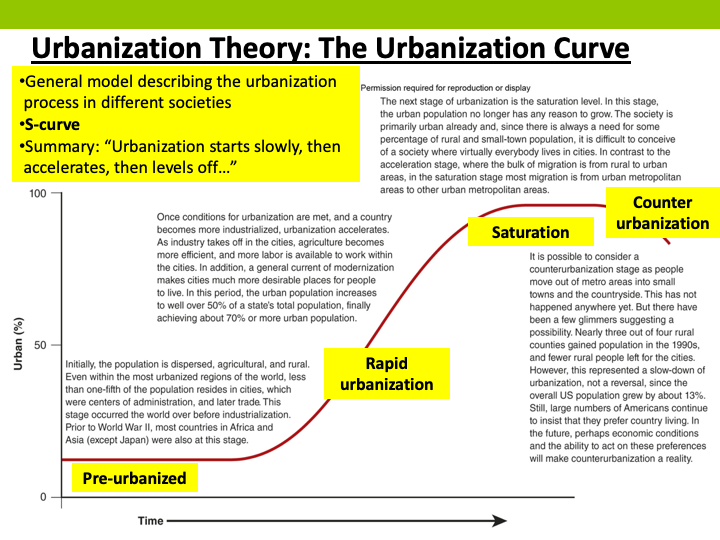

# Ch 11: City Spaces: Urban Structure

Ch. 11: “The Informal Economy” -> end of chapter - Pages 416-423

## The Informal Economy

- In peripheral cities >1/3 of population is engaged in the informal sector
- > 1 billion people in the world
- e.g Street vending, shoe shining, craft work, street-corner repairs, garbage scavenging
- e.g Begging, crime, prostitution
- Children need to work as well
  - Sweatshops
- Positives
  - Pedicabs are non-polluting
  - Garbage picking allows recycling
- Effect on formal sector
  - Provides cheap goods and services that reduce cost of living
  - Companies can keep wages low and remain competitive
- Informal economy not taxed, so governments have no funds to improve conditions

## Slums

- Overcrowding due to unemployment, underemployment, poverty
- More people than available cheap housing
- Makeshift shanty housing gets built on the cheapest, least desirable sites
- Governments evict and demolish slums
  - Seoul and Beijing can afford to build new low-income housing
  - Many peripheral cities cannot afford to build new housing, so dwellers built new slums in a different part of the city
  - Now see slums as a result of poverty
    - Affordable
    - Provides introduction to city life for migrants
- In Latin America, activists plan to quickly invade land and build shanty housing
- Self-help: people improving their housing over time
- Some slums have terrible conditions
  - Low access to sanitation
  - High disease
- Negatives
  - Lack of opportunities
  - Crime (Sexual abuse, Gangs)
  - Settlement not acknowledged by officials
  - Unsafe conditions
  - Standing water,garbage
  - Risk of natural hazards (flooding, fire)
- Positives
  - Affordable housing
  - Away from monotony/poverty of rural life
  - Sense of community
  - Learn about large city
  - Immediate source of livelihood (e.g Garbage scavenging)
  - Self-employment

## Transport and Infrastructure Problems

- No tax revenue, so the city cannot build infrastructure (transportation, schools, utilities, emergency services)
  - Many traffic accidents
- Homes are far from work; people commute
- Terrible traffic, gridlock due to bad roads
- Low access to water
  - Water taps only run during limited times in a day
  - Taps are far away and people need to to carry water over distances
  - Cannot afford piped water in homes
  - Opportunity: sell bottled water
- No garbage collection
  - Garbage is informally recycled, thrown into water streams or left to rot
  - Sewage is not treated
  - Opportunity: handcart waste collection

## Environmental Degradation

# Economics

## Economic Sectors

1. Primary
   - Harvest or extraction
   - e.g Agriculture, fishing, forestry, mining
2. Secondary
   - Value added
   - Manufacturing, processing, construction
3. Tertiary
   - Service
   - e.g Tourism
4. Quaternary
   - White-collar / executive services
   - Information
   - Highly specialized
   - Spatially independent
5. Transportation and utilities

## Spatial Aspects

- Strong ties: primary and some secondary
  - Resource location
  - Labour moves to where resources are
- Weak: secondary, tertiary, quaternary
  - Locate near the customer
  - Manufacturing Factors of production
    - Direct: raw materials, labour, markets, energy
    - Indirect: technology, transportation, infrastructure, financial system, taxes
    - e.g Aluminum smelting is in Kitimat, BC far from extracting site in Australia because
      - there is cheap hydro and
      - a deep water port for transportation
- Transportation modes
  - Water, rail, road, air, pipeline
- **Least-cost theory**: point at which total of all costs associated with industry are minimized
  - Use computer models to calculate the best location
  - e.g auto plants are located in north east USA
- **Location interdependence theory**: industries locate near each other
  - AKA agglomeration
  - Location monopolies
  - Equal market access
  - Mutual advantage from nearby industries
  - e.g Silicon Valley
    - Skilled labour + innovative technology + venture capital + reliable infrastructure + *locational interdependence*
  - e.g TO Entertainment district

### Global production

- **Outsourcing**: sub-contracting work to arms-length/independent companies
  - Cost reduction
  - Flexibility in production
  - Local or foreign
- **Offshoring**: moving operations from high to low cost countries

## Post-Industrial Economies

- Economies with rapidly declining primary & secondary economies
- Focused on tertiary and higher sectors
  - e.g Financial services, IT, consulting, data mining

# Ch 4: People and Nature

- Start of chapter -> ”Environmental Philosophies and Political Views of Nature” + “Human Action and Recent Environmental Change” -> end of chapter.
- Pages 112-125, 133-152

## Human Impacts on Environment

- Humans greatly modify and impact the environment
  - Resource consumption
  - Waste production
  - Habitat modification to produce food

## Nature as a Concept

- Society shapes and controls nature
- Global leaders had many conferences discussing environmental protection and sustainable development, but no concrete agreements
- Human population is growing, and resource consumption is higher
- Positive changes
  - National ministries to monitor environmental improvements
  - Phasing out leaded gasoline, DDT, ozone-depleting chemicals
  - Growing public interest in the environment
  - More concern for sustainability
- Technology is not a solution to environmental problems

### Nature and Society Defined

- **Nature**: physical universe + social creation
  - Reflection of society
- **Society**: sum of inventions, institutions, relationships created and reproduced by human beings across places and times
- Society shapes people’s understanding and uses of nature
- Nature shapes society
- Technology mediates the nature-society relationship
- **Technology**:
  - physical objects or artifacts (e.g the plow)
  - activities or processes (e.g steel-making to produce a plow)
  - knowledge or know-how (e.g plow-based agriculture)
- **Human Impact**: any *change* (positive or negative) caused by the *actions of humans*
  - Can be direct or indirect
  - e.g Hoa Binh dam in Vietnam
    - Direct impact: water reservoir
    - Indirect impact: increased sediment in water, making it pink
- Quantifying human impact
  1. **Ecological footprint**: measure of biologically productive land area (biocapacity) required to support a given population by providing for its needs and absorbing its wastes
     - Includes resources used from all over the globe
     - Helps visualize growth and scale of humans on Earth
     - Global average: 2.84 hectares per capita
     - Earth biocapacity: 1.73 hectares per capita
     - Canada: 8.17 hectares per capita
  2. **I = PAT**
     - Impact on Earth’s resources = Population * Affluence (per capita income) * Technology (factor)
     - Relates human pressure on environment to level of affluence and technology
     - Population: less people means less pressure on resources
       - But more people means greater labour force
     - Affluence: high affluence is a drain on resources
       - Core countries with high affluence are more effective in protecting their environments
         - However they do so by exporting waste elsewhere
         - But that increases affluence of developing countries
     - Technology:
       - Affects environment by
         - harvesting of resources
         - emission of wastes in manufacture of goods and services
         - emission of waste in the consumption of goods and services
       - Technological innovation shifts demand of resources
       - Technology can be a solution or a problem
         - e.g Nuclear is cleaner than fossil fuels
     - All these factors have complex effects on the environment

### Nature-Society Interactions

- **Cultural ecology**: study of how human society *adapted* to environmental challenges
  - e.g Irrigation for arid soil, terracing for steep slopes
  - e.g Agricultural chemicals
- Humans modify environments and landscapes
- Can result in environmental degradation or pollution
- “Social production of nature”: refashioning of landscapes and species by human activity (e.g capitalist production and labour processes)
- Fossil fuels + land use cause global warming
  - Results in more extreme weather
  - Political aspect: lower income people are more at risk
  - Core countries produce carbon dioxide emissions
  - Peripheral countries burn coal and deforest environment
- **Political ecology**: relating patterns of resource use to political and economic factors

#### Agrochemicals: DDT

- Used as an insecticide to control malaria and typhus
- Little understanding of toxicity or bioconcentration
- Book “Silent Spring” written by Rachel Carson
- DDT destroys bird egg shell
- Dying bald eagles made americans ban DDT

### Geomorphic Agent

- Something that moves soil, sediment or rock
- Tectonic activity
  - Plate movement
  - Volcanoes
  - Earthquakes
- Surface activity
  - River
  - Wind
  - Glaciers
  - Waves
- Humans
  - Largest factor (45000 tons of earth moved per year)
  - We build giant construction machines to move earth
  - Logging activity
  - Mining
  - Dams

### Water Politics

- **Virtual water**: water embedded in the production of food or other consumables

## Human Action and Recent Environmental Change

- Industrialization had the biggest impact on the environment
- Also urbanization
- **Anthropocene**: modern geological era where humans have dramatically affected the global environment
  - Disagreement of whether this began with Industrial Revolution or rise of agriculture

### Impact of Energy Needs

- Most of world population relies on nonrenewable energy resources

#### Fossil Fuels

- Proportions of world’s current supply of primary energy:
  - 32% oil
    - Produced in Middle East
  - 29% coal
    - Produced in China
  - 21% natural gas
  - …
  - 5% nuclear
    - Core countries
  - 2% hydro
  - 1% renewable sources
- Energy consumption increasing
  - Affluent core regions have higher energy consumption
- Every stage of energy conversion impacts nature
  - Mining depletes vegetation and topsoil
  - Burning things releases harmful chemicals
    - Natural gas is relatively clean
- **Hydraulic fracturing (fracking)**: injecting pressurized mix of water, sand, chemicals into bedrock to create artificial fractures
  - Fractures allow oil and gas to flow into the borehole and be extracted
  - Uses lots of water and toxic chemicals

#### Nuclear Energy

- Cleaner and more efficient than fossil fuels
- Safety concerns of meltdowns (e.g Chernobyl, Fukushima)
- Some countries banned nuclear energy
- Some countries building new nuclear plants
- Problem of how to dispose nuclear waste

#### Biomass Fuels

- Periphery countries rely on biomass (wood, animal dung) for energy
- Air pollution from wood burning
- Easier to extract than oil or gas
- Deforestation to get firewood

#### Hydropower

- Dams change the ecosystem
  - Changes aquatic ecosystem, downstream flow, etc
- Changes surrounding ecosystem due to weight of water
- Drowned vegetation decompose and produces methyl mercury which bioaccumulates
- Waters incubate mosquitoes that carry disease
- Dam projects usually on aboriginal lands

#### Energy-Related Pollutants

- Hydro produces less pollutants
- Coal, gas, factories, cars cause atmosphere pollution
- Causes **acid rain**
  - Europe is recovering due to stronger environmental regulations
- China has the world’s worst air pollution
  - Asian Brown Cloud of pollutants hovers over Asia during the winter
  - Reduces solar radiation reaching the Earth’s surface, reducing plant productivity and trapping heat

#### Alternative Energy Sources

- Solar, wind, geothermal, tidal energy is clean
- Wind is super successful
- Solar: China’s been flooding the global market with solar panels
- We are reducing energy consumption with more efficient appliances

### Impact of Land-Use Change

- Land is cleared for fuel, farming, grazing, resource extraction, highways, energy generation
- Land categories:
  - Forest
  - Cultivated land
  - Grassland
  - Wetland
  - Areas of settlement
- Land changes through:
  - *Conversion*: wholesale transformation of land from one to another
  - *Modification*: altering of existing land use
- Lots of forest land has been changed

#### Forest

- **Deforestation**: permanent clearing and destruction of forests
- Loss of biodiversity
- Destabilizes oxygen and carbon dioxide cycles of the forests
- Peripheral countries cut forests to expand economy
  - Hardwood logging, livestock land, cocoa production
- Forestry industry clear cuts forests to produce lumber and paper
- Core countries replant forests, farmers let forest take over
- Peripheral countries have accelerated forest clearing

#### Cultivated Lands

- Expansion of croplands since 1700
- Croplands in core region now constant or decreasing
- Peripheral countries have expanding cropland
- Growing population and outsourcing of food production to peripheral countries
- “Land grabs”: corporation and countries purchasing agricultural land in other countries
  - Guarantee of future food supplies

#### Grasslands

- Used as pasture for livestock
- Human impacts:
  1. Conversion of grassland for other uses (settlement)
  2. Degradation from overgrazing
     - **Desertification**: spread of dessert conditions due to deforestation, overgrazing, poor agricultural practices
     - e.g Grasslands bordering Sahara Desert

#### Wetlands

- Swamps, marshes, bogs, peatlands, shores of bodies of water
- Draining/filling wetlands and converting to settlement or cultivation
  - e.g San Francisco converted wetlands near the bay to expand downtown
- Modification of wetlands changes water quality and ecosystems

## Globalization of Environment

- **Global change**: combination of political, economic, social, historical, environmental problems that all humans need to deal with

### Environmental Sustainability

- Most environmental threats are in peripheral countries
- Environmental pollution and degradation will cause a catastrophe
- Peripheral countries have less money to cope with threats
- *Sustainable development*: obligation to preserve resources and landscapes for future generations
  - Ecological, economic, social measures to prevent environment degradation but still have economic growth and social equality
  - Impacts on environment should be benign or manageable

## Marine Environments

- 5 main threats to reefs
  1. Overexploitation
     - Fishing and unsustainable use
     - Anchor damage
     - Bomb fishing
     - Cyanide fishing
  2. Coastal development
     - Tourism and recreation
     - Dredging
     - Construction materials
     - Building on reefs
     - Sewage
     - Sediments
  3. Inland pollution and erosion
     - Soil and sediment from deforestation and inappropriate farming practices
     - Plastics / other litter
       - North pacific gyre (trash vortex)
       - Microplastics are bad
         - > 85% of plastic in ocean is microplastics
         - Cannot be cleaned up by shoreline cleanups
       - Trash water wheel used in Baltimore
       - Coraball: kickstarter for thing in laundry that catches plastics
     - **Non-point source pollution**: millions of points of origin
  4. Marine pollution
     - Oil spills
     - Debris
       - Shipping containers: **10000/yr**
  5. Climate Change-related Ocean warming
     - Coral bleaching
     - High water temperature triggers coral bleaching, which kills the coral

## Movie: (Special Report: A Plastic Tide) (on youtube)

https://www.youtube.com/watch?v=D35YnZ7_WxM

- Plastic graveyard
- Birds and fish with plastic in their bodies
- Mumbai, India
  - Beach has plastic that comes from the sea, brought in by the tide
  - Started beach clean effort
    - Hard to deal with scale of problem
    - Helps with local beach and tourism
  - No point fishing on that beach
  - Plastics are useful (e.g toys)
  - **Plastic never completely breaks down**
  - 300 million tonnes of plastic produced per year
  - Single use plastics are the worst
  - Trash goes into gutters and directly into streams into sea
  - Find 1-2 pieces of plastic / m^3 of seawater
  - Sand has small pieces of plastic
- Examine bird stomachs to estimate amount of plastic in ocean
  - Birds lose fat and die slowly
  - Plastic in gizzard gives a false sense of satiation
  - Big birds (e.g albatross) have bigger objects
- **Ghost nets**
  - Fish nets get caught by reefs
  - Fish then get trapped in the nets
  - Plastic is strangling life
  - **Plastic kills corals, which protects our beaches**
  - **Plastic goes up the food chain into our life**
    - e.g microplastics in mussels
    - Microplastics can enter bloodstream -> unknown effect
    - **Microplastic**: <5mm in size
- Island somewhere
  - Plastic tucked into coral and rocks, or floating
- 5 great gyres of plastic
  - North+south pacific, north+south atlantic, indian
  - Oceans are connected, garbage can travel anywhere
- *Only way to stop the plastic tide is to manage it in a better way*
- Ocean plastics problem
  - Non-point source pollution problem
  - Cumulative environmental impact (additive)
  - 10 rivers contribute 85% of plastics
    - Logical starting point for prevention & interception?

### Products made of plastic

- Useful life (how long product is used before being discarded)
- Plastic stir stick: 10 seconds
- Wet wipes: 1 minute
- Plastic bag: 1 hour
- Food packaging: 2 weeks
- Shampoo bottle: 3 months
- Plastic pen: 3 months - 5 years
- Reusable water bottle: 2 years
- Artificial Xmas tree: 10-15 years
- Plastic chair: 30 years

### Actions to reduce plastics in oceans

- **Preventing**
  - Change throwaway culture
    - Ban single use plastics (e.g bags, straws, cutlery)
    - Shopping bag charge
- **Intercepting**
  - Filters in storm drains
- **Removing**
  - Beach cleanup
  - Trash water wheel